# 论谷歌浏览器插件的修改

## 项目背景

最近下载了一个超级棒的谷歌浏览器插件**Momentum**，感觉挺好用的，而且画面简洁，超级漂亮！

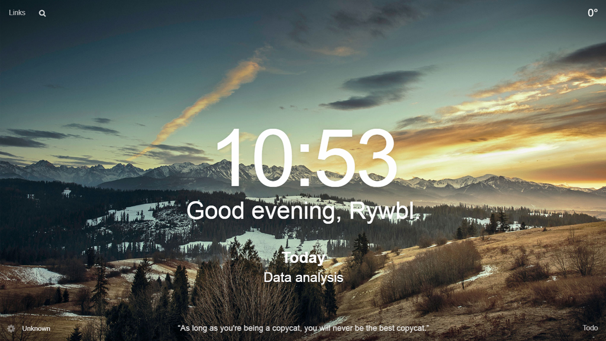

自带适中，天气，计划及搜索小工具，而且有好看的高清图作为背景，用作浏览器空白页真的是太棒啦！

在试用了几天之后，发现默认搜索使用的搜索引擎是一个国外的网站，不知道是服务器挂了还是被墙了，打不开，于是动收魔改插件，使其彻底适用于我兔之网络环境!

原理

### 什么是谷歌浏览器插件

emmmm,翻了一大堆资料后发现应该就是一个好看的网页然后通过js等框架封装成了一个小程序供浏览器调用罢了...

### Chrome浏览器插件通用结构

和大多数程序一样，一个main的入口，然后调用一堆函数和方法为止服务

```
参考链接
1.如何编写浏览器插件：https://zhidao.baidu.com/question/309378180633708164.html
2.Chrome浏览器插件教程：https://www.jianshu.com/p/51c650f98d9c
...
```

搞定了简单结构和原理，然后我觉得应该就魔改插件就够用了，于是进入下一步！

## Step 2:分析Momentum插件结构

嗯，新版浏览器的通病，无法使用crx格式安装，所以我加载的是未封装的Momentum插件，所以它的结构就很明白咯！  
嘿嘿

这里为了方便大家看，就临时做了个导图！

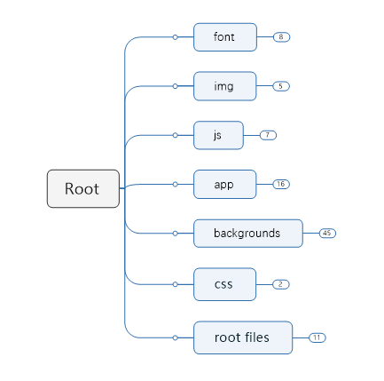

2020年2月24日23:37:09 未完待续

0.根目录下主要是图表和入口文件还有原始网页咯  
1.backgrounds下面就是缓存（下载）背景图片  
2.app下主要就是各种功能实现的js方法  
...

其他的目前没看懂，不过不影响！

## Step3 F12开发者工具网页抓包

通过开发者工具定位新Tab页面的指定元素，然后查找对应的失效链接位置  
在搜索页面输入测试搜索文字，然后得到对应的搜索引擎的地址

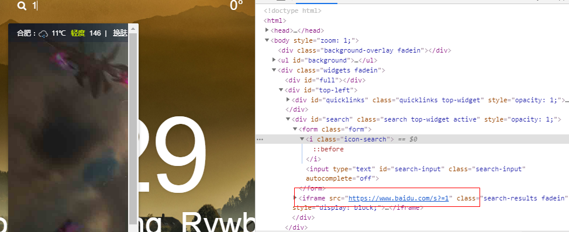

## Step4 js手动修改

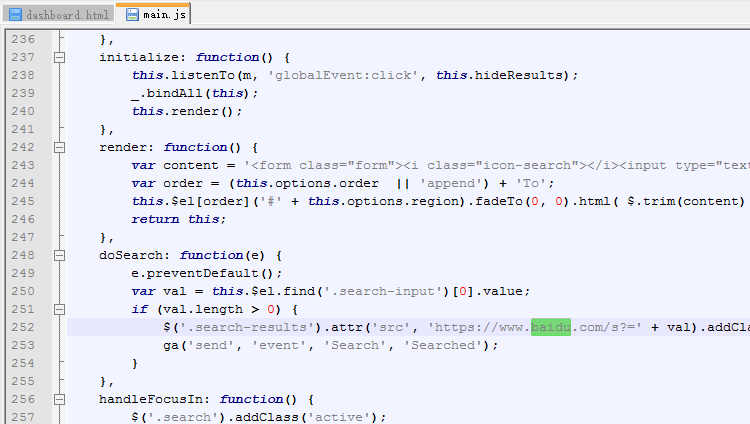

2020年2月25日21:35:07  
以上吧，记录终止，Closed

## 进阶想法

1.熟悉js语法，输入搜索语句将搜索结果在新标签页中显示出来....  
有时间再去做咯~